# User Guide for ChromaPave

hemi luan

2025-11-04

**ChromaPAVE** is a freely available, open-source Windows client application specifically engineered to accelerate and enhance quantitative mass spectrometry experimentation, with a dedicated focus on small molecule analysis. It provides an integrated, end-to-end workflow—from processing raw acquisition files to rigorous data quality control—empowering researchers to derive robust, biologically meaningful conclusions from their LC-MS data. Powered by the statistical computing prowess of the R language and architected within a user-friendly Electron framework, ChromaPAVE democratizes advanced data processing. It provides a free, user-friendly platform to significantly reduce the impact of potential noise and contaminants encountered in chromatographic feature lists generated from untargeted metabolomics studies.

**Main modules**: Tune, Features and SmartChrom

[figure not shown]

Interface of ChromaPave

## Modules: Tune

#### 1. Opening LC-MS Files

1. Click the Select LC-MS data files button and select mzML or mzXML files containing MS1 spectra.
2. Select one of preferred MS data files to display the TIC and BPC plots, as well as the MS1 spectra in each scan.

[figure not shown]

#### 2. Parameter Options for Peak picking

3. To define input parameters for peak picking, click on Features analysis to run the XCMS modules. The extracted features and summary information will be shown in Feature View.
4. To visualize a targeted feature for a specific m/z and retention time, define the mz and expected_RT, and click the Start analysis to extract the mass traces (ROIs, top-layer) and XIC (bottom-layer).
5. Click the Save button and select the folder path where you want to save the parameter file.

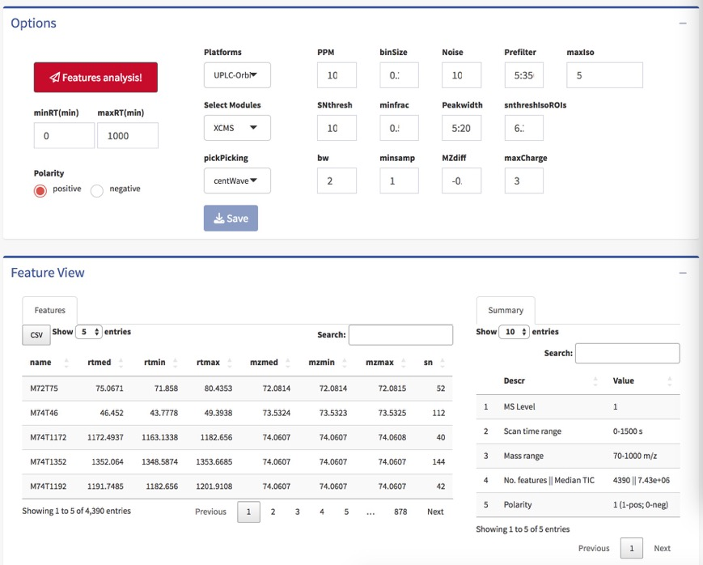

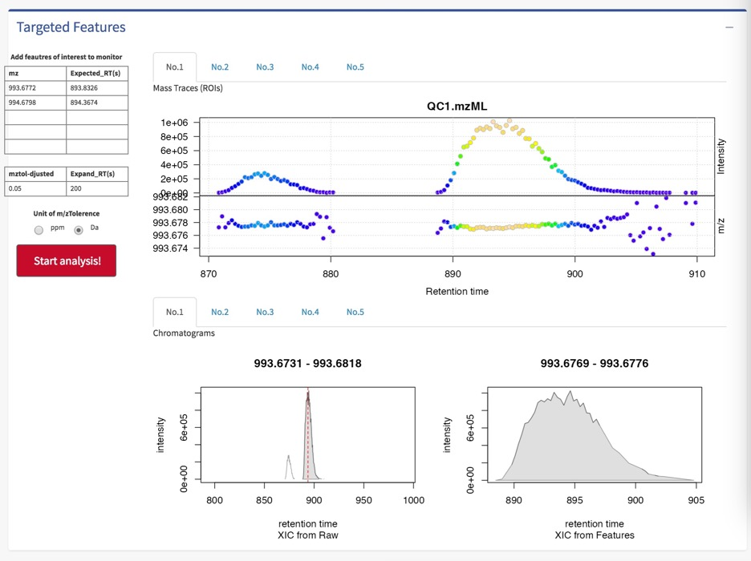

##### **Parameters (from XCMS package)**

##### Peak picking (centWave algorithm)

ppm: the maximal tolerated m/z deviation.

Snthresh: the signal to noise ratio cutoff.

peakwidth: the expected approximate peak width in chromatographic space. Given as a range (min, max) in seconds.

noise: to set a minimum intensity required for centroids to be considered in the first analysis step (centroids with intensity < noise are omitted from ROI detection).

prefilter: the prefilter step for the first analysis step (ROI detection). Mass traces are only retained if they contain at least k peaks with intensity >= I.

mzdiff : the minimum difference in m/z dimension required for peaks with overlapping retention times; can be negative to allow overlap. During peak post-processing, peaks defined to be overlapping are reduced to the one peak with the largest signal.

##### Peak grouping (The peak density algorithm)

bw: the bandwidth to be used.

minFrac: the minimum fraction of sam- ples in at least one sample group in which the peaks have to be present to be considered as a peak group (feature).

minsamp: the minimum number of samples in at least one sample group in which the peaks have to be detected to be considered a peak group (feature).

binSize : the size of the overlapping slices in m/z dimension.

## Modules: Features

1. Click the Select MS data files button and select mzML or mzXML files containing MS and/or MS/MS spectra (DDA mode).
2. Click the parameters button, and upload the parameter file. If the parallel processing is selected, multiple processors can be used and minimize the computation time. A represented XIC for each feature will be generated if the Chromatogram spark is selected.
3. Click on Start analysis to run the Peak Picking.The Features Module will generate a .cpva file at the data folder, containing the processed data.

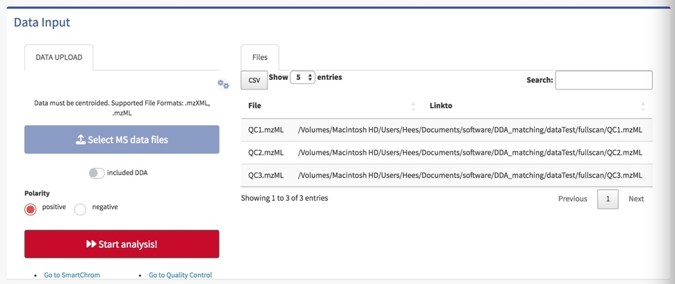

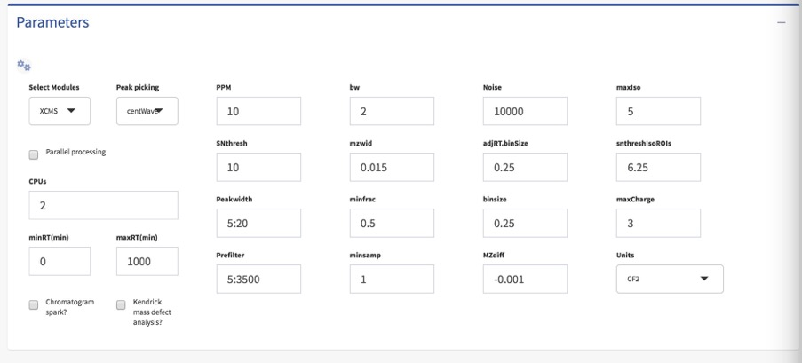

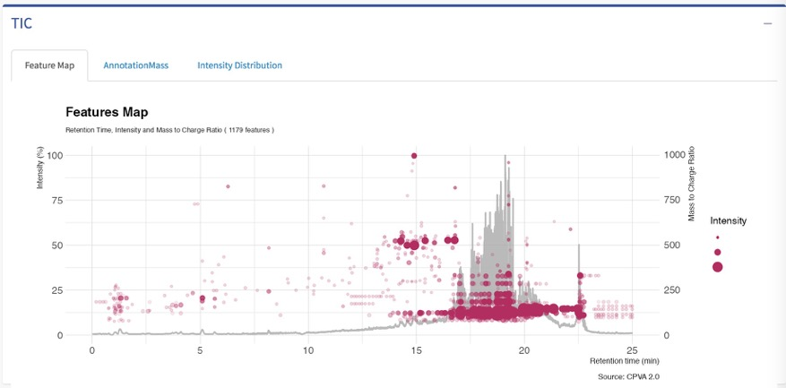

Global overview of chromatographic peaks

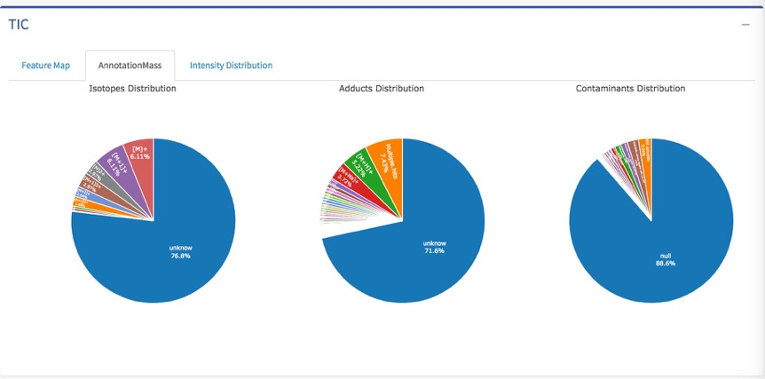

Annotation of adducts, isotopes and background contaminants

4. Click on Save button to update any changes (name) in the peak table.

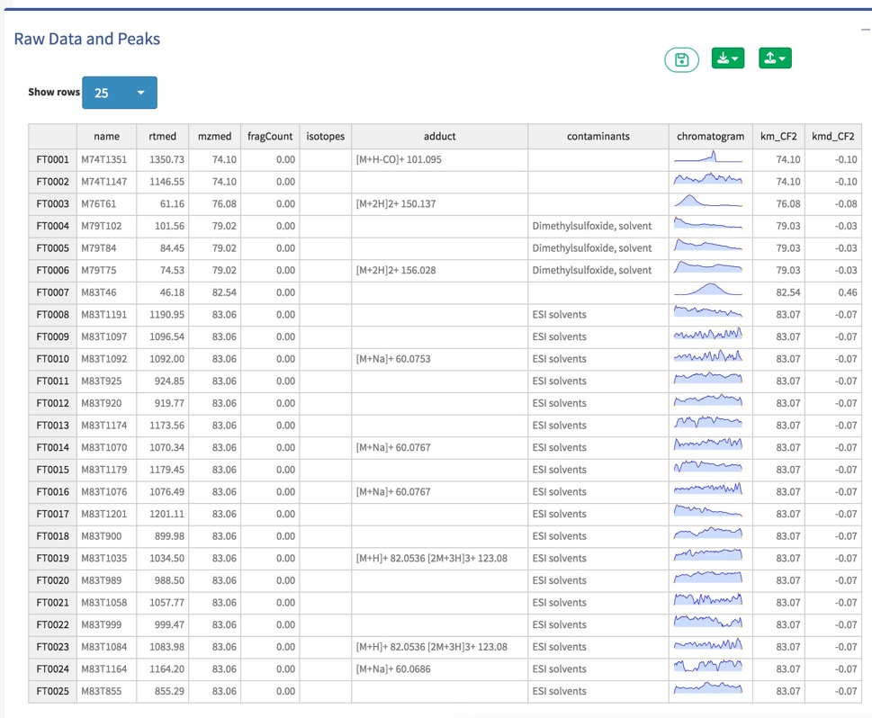

5. Click on Download button to download the feature table and MS/MS spectra corresponded to features.
6. Click on upload button to recover the processed data from an cpva file.

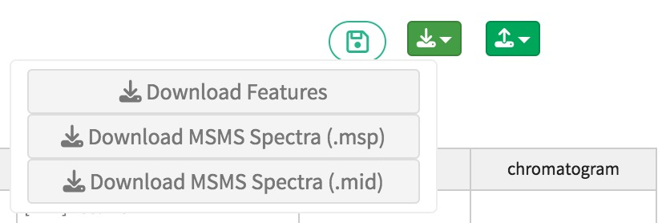

## Modules: SmartChorm for Quality evaluation of chromatographic peaks

7. Click the Start analysis button to extract the XIC and its metrics for all features.
8. Click on Calculate button to visualize chromatographic quality of features according to predefined metrics. Red, low-confidence; Blue, high-confidence
9. Click the Save button and select the folder path where you want to save the feature table.
- These steps (h-j) can be skipped.

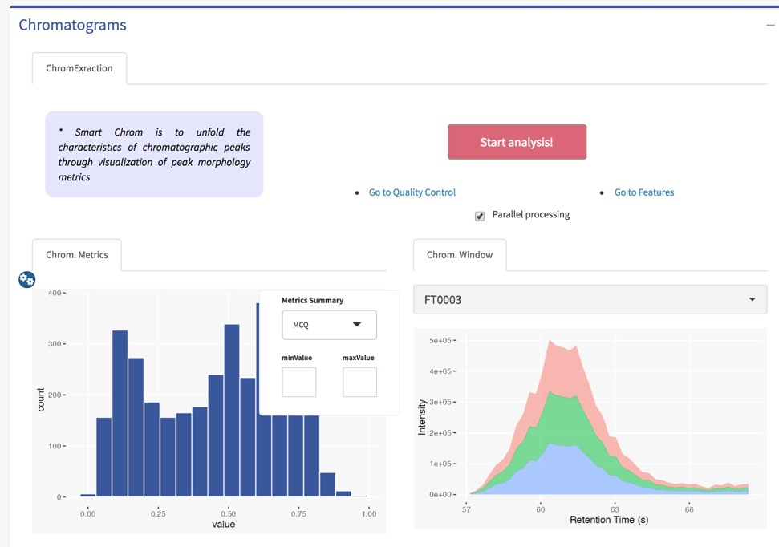

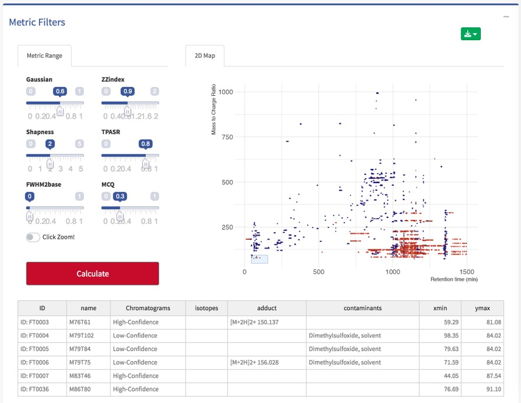

## Modules: IS2Normalization

10. If there are internal standards (IS) in the features, ISRT can be used for normalization. IS index should be included in the name of features.

Click the Check IS button to view the intensity of IS features, and then Click the Correction button for normalization of all features.

11. Click the Correction button for normalization of all features by using four normalization methods (IS free).
12. Click the Save button and select the folder path where you want to download the normalized features.

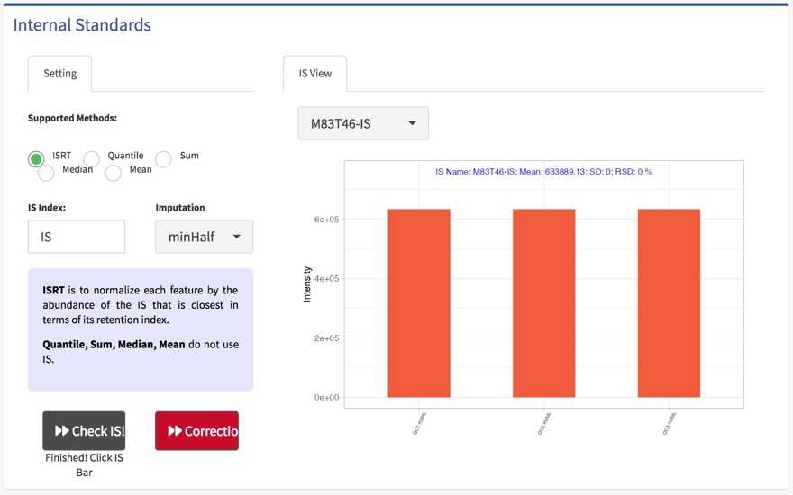

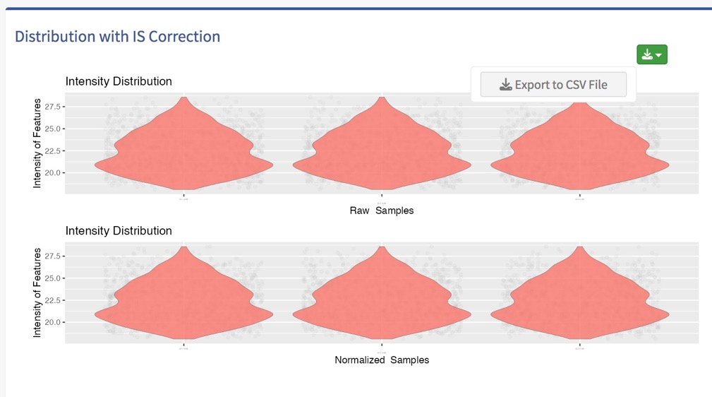

13. Click the Download the Template button and edit the meta.csv files, containing ID, samples, Valid, Order and Batch information.
14. Click the Browse button and upload a .meta.csv file
15. Click the Check button, the format will be checked.
16. Click the Start analysis button and perform the QC-based Normalization with default parameters.
17. Click the Download button and download the normalized features. *QCRFSC and QCRLSC methods can be selected.*  
    imputation method.(i.e., nearest neighbor averaging, “KNN”; minimum values, “min”; Half of minimum values “minHalf” median values, “median”. (Default: KNN)

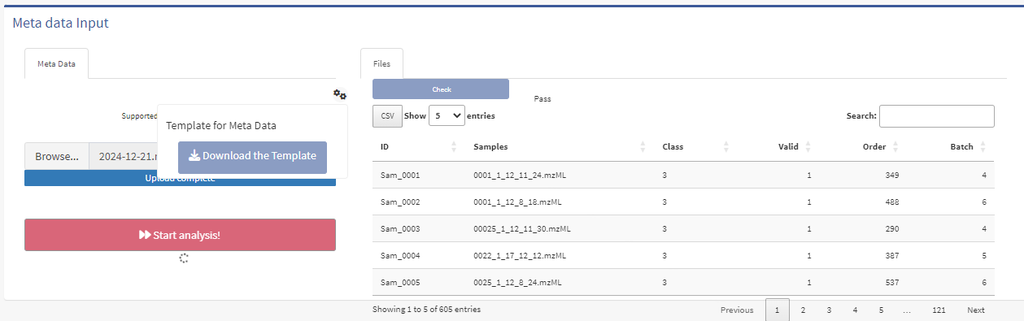

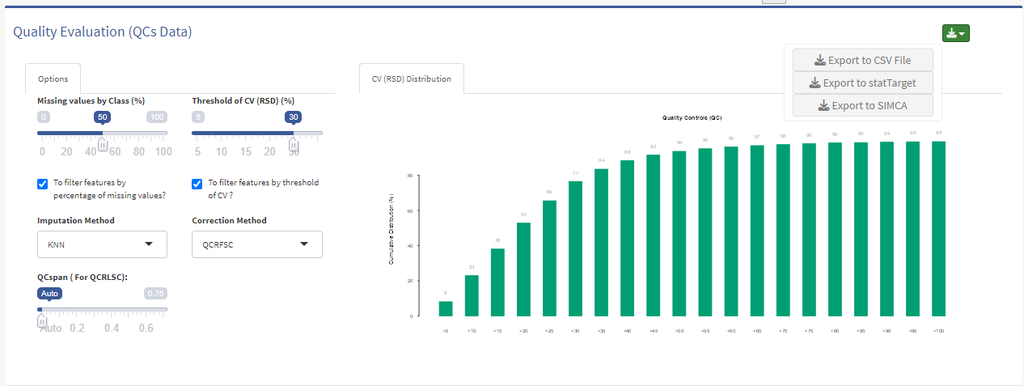

The RSD distribution of QCs after correction

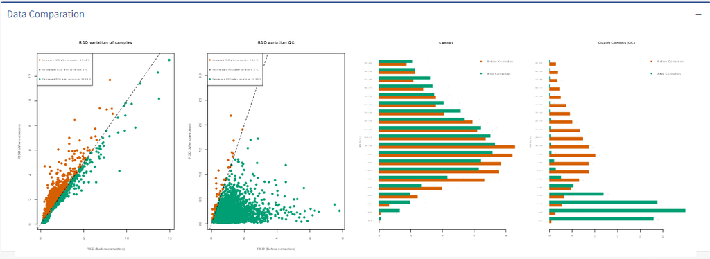

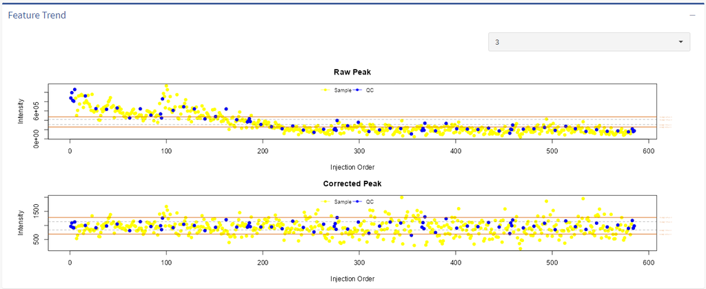

The quality control images for each feature